# analyse 0da6 8nov21_8h-9h

## Elbow method to calculate eps

The method proposed here consists in computing the distances between the k nearest neighbors in a matrix of points.

The idea is to calculate the average of the distances from each point to its k nearest neighbors. The value of k will be specified by the user and corresponds to MinPts.

Then, these k-distances are plotted in an increasing order. The objective is to determine the “knee”, which corresponds to the optimal eps parameter.

A knee corresponds to a threshold where an abrupt change occurs along the k-distances curve.

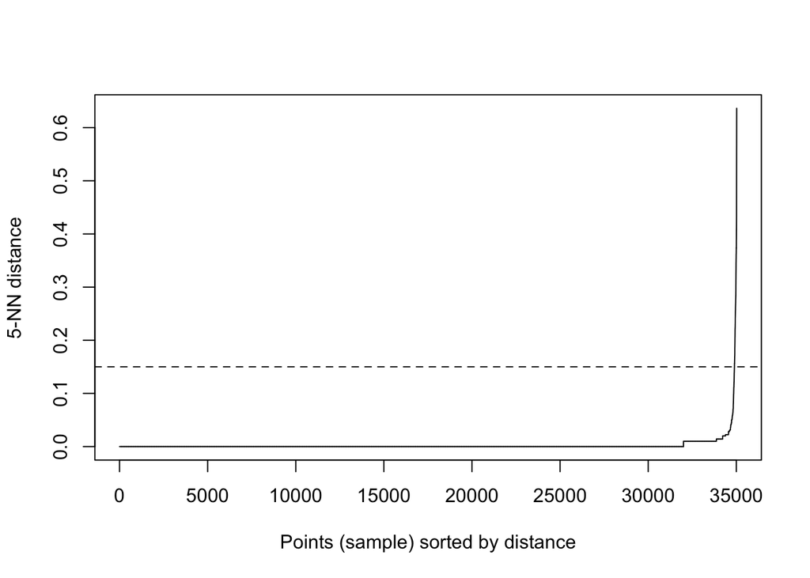

```
## DBSCAN clustering for 35023 objects.
## Parameters: eps = 0.15, minPts = 5
## The clustering contains 7 cluster(s) and 83 noise points.
##
##     0     1     2     3     4     5     6     7
##    83 34882    20    10     9     5     5     9
##
## Available fields: cluster, eps, minPts
```

```
## [1] 8
```

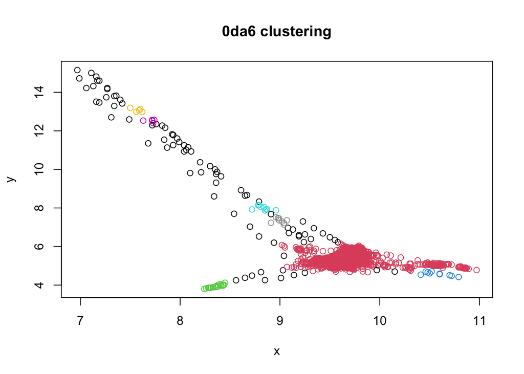

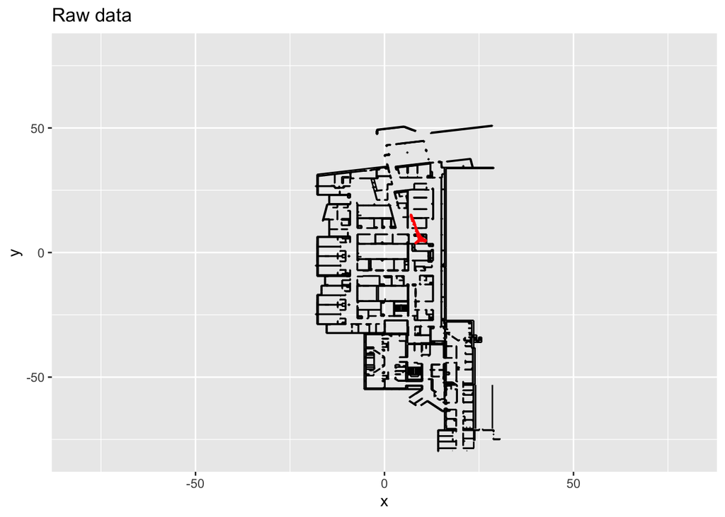

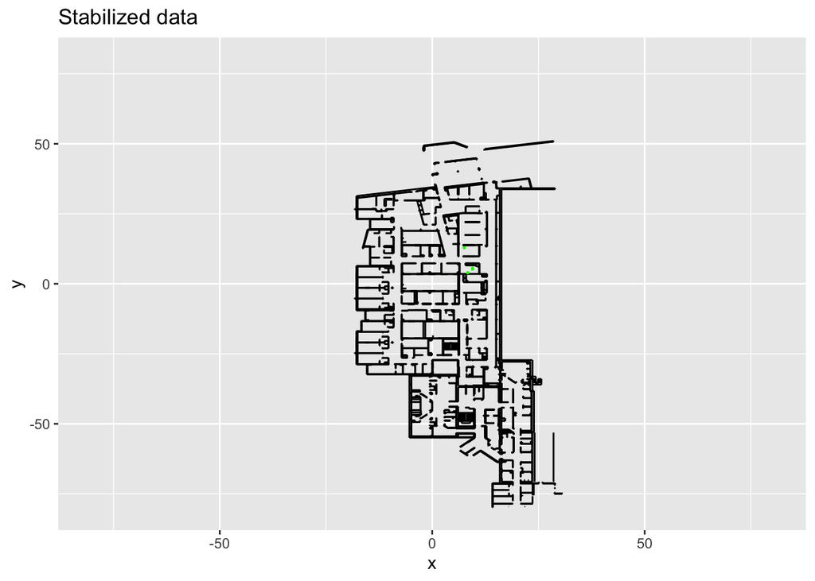

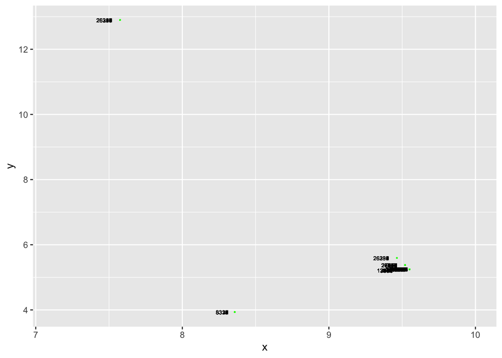

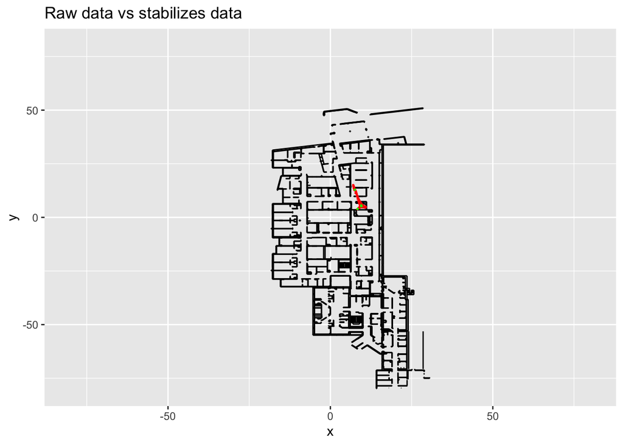